# Building Shiny App around UDPipe NLP workflow.

## Srinivasa Chakravarthy: 11910069,

## Poonam Sampat: 11910083 &

## Amit Ombase: 11910042

#### This assignment requires to create a Shiny App, which helps to do POS tagging of the document, annnotate the same using UDPipe. The annotated structure is used to create word cloud and have used co-occurance UDPipe.

### We’ve also added our code to github @ https://github.com/amitombase/Shiny-Apps

# Glimpse of application:

## Preview of App when it starts

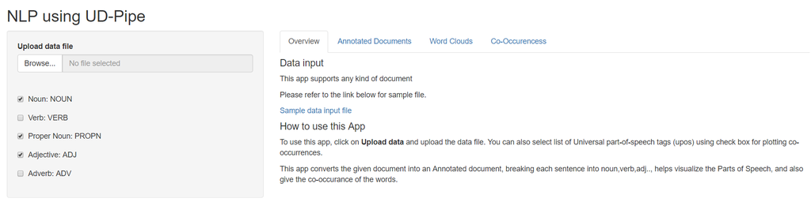

## Loading user’s data

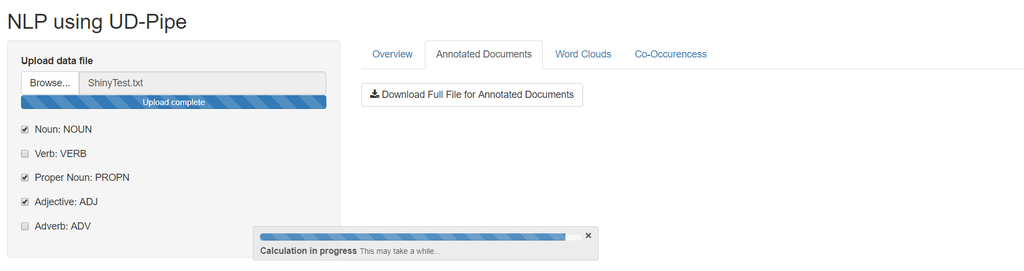

## Annotated Doc displayed

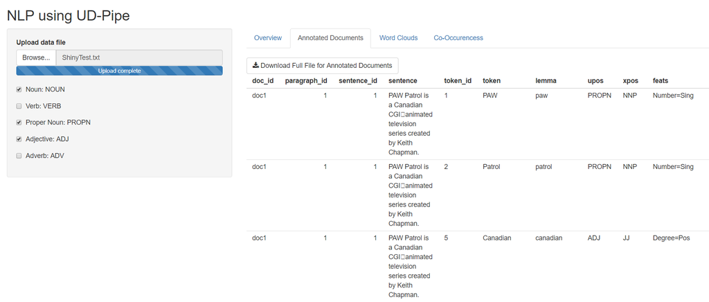

## Downloaded file for complete Annotated documents

[figure not shown]

## Word Clouds Noun & Verb

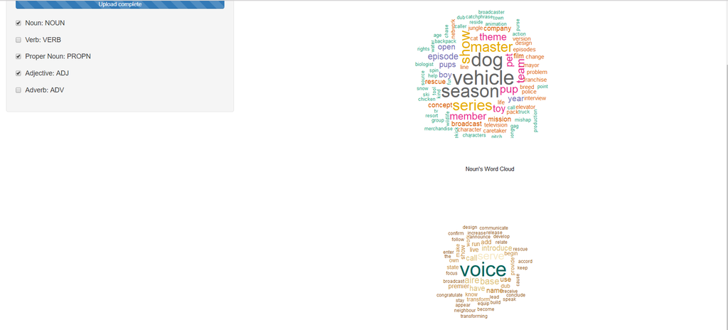

## Co-Occurences-1

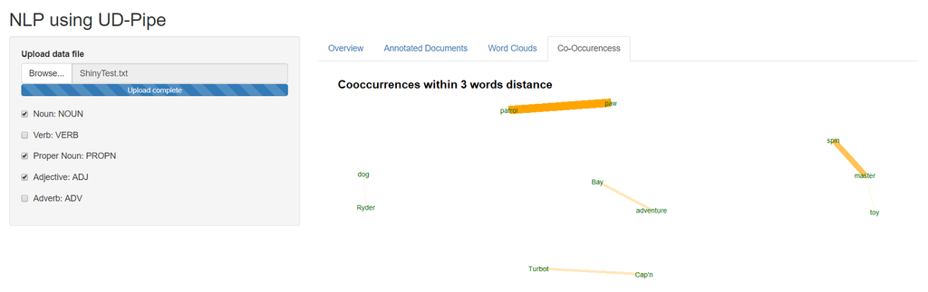

## Co-Occurences-2

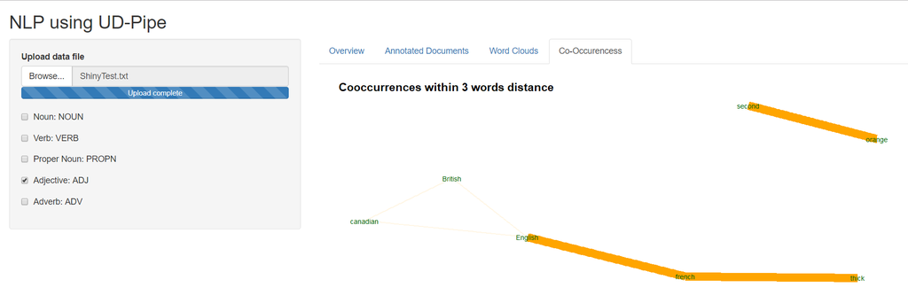

## Co-Occurences-3

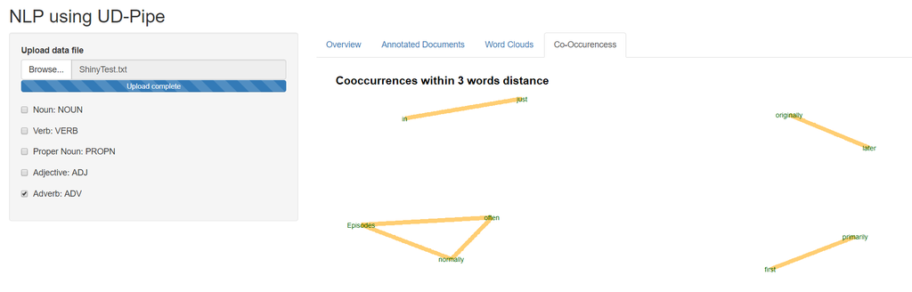

## This document gives us a walkthrough of server & ui logic of a Shiny web application that we’ve coded.

To run the Assignment you need to open the *server.R* & *ui.R* attached in submission folder. Once these files opened, you simply have to click the *Run* button in RStudio.

Find out more about building applications with Shiny here: http://shiny.rstudio.com/

# Walkthough of SERVER.

### Define required libraries.

```r
library(shiny)
if (!require(udpipe)){install.packages("udpipe")}
if (!require(textrank)){install.packages("textrank")}
if (!require(lattice)){install.packages("lattice")}
if (!require(igraph)){install.packages("igraph")}
if (!require(ggraph)){install.packages("ggraph")}
if (!require(wordcloud)){install.packages("wordcloud")}

library(udpipe)
library(textrank)
library(lattice)
library(igraph)
library(ggraph)
library(ggplot2)
library(wordcloud)
library(stringr)
```

### Read the given input file and store it in a variable so it can be passed to other tabs.

- Here we are reading the file and using UDPIPE library to tokenize the data into Parts of Speech.
- We are performing Parts of Speech tagging here. The output of Below Method is dataframe that has all words with their POS identified.
- ?udpipe_download_model # for langu listing and other details
- load english model for annotation from working dir
- now annotate text dataset using ud_model above
- system.time({ # ~ depends on corpus size

```r
shinyServer(function(input, output, session ) {

  selectedData <- reactive({
    readLines(input$file1$datapath)
  })

  downloadData <- reactive({

    setwd('F:/ISB-CBA/Term-1/Residency-2/TA by Prof Sudhir Voleti/Group Assignments/Assignment 2 Shiny Apps/GroupAssignment_2');  getwd()
    df <- selectedData()
    dataread  =  str_replace_all(df, "<.*?>", "") # get rid of html junk
    english_model = udpipe_load_model("./english-ud-2.0-170801.udpipe")  # file_model only needed
    x <- udpipe_annotate(english_model, x = dataread) #%>% as.data.frame() %>% head()
    x <- as.data.frame(x)
    return (x)
  })
```

### Below Method is the interface to the UI second tab that shows the Annotated Content.Define server logic required to support the UI

- Shows a progress bar.
- Calls the the downloaddata() which has the data tagged with POS.
- Filters the POS selected by the user.

```r
  output$Summary <- renderTable({

    progress <- Progress$new(session, min=1, max=15)
    on.exit(progress$close())

    progress$set(message = 'Calculation in progress',
                 detail = 'This may take a while...')

    for (i in 1:15) {
      progress$set(value = i)
      Sys.sleep(0.5)
    }

    myList = list()
    if (input$VERB == TRUE) {myList[[length(myList)+1]] <- "VERB"}
    if (input$ADV == TRUE)  {myList[[length(myList)+1]] <- "ADV"}
    if (input$ADJ == TRUE)  {myList[[length(myList)+1]] <- "ADJ"}
    if (input$PROPN == TRUE){myList[[length(myList)+1]] <- "PROPN"}
    if (input$NOUN == TRUE) {myList[[length(myList)+1]] <- "NOUN"}

    selected <- return (subset(downloadData(), upos %in% c(myList)))

    return (head(selected,100))

  })
```

### Below Method supports the download button in the UI.It uses as the download() method to prepare the file for download.

```r
  output$Download <- downloadHandler(
     filename = function() {
       paste("Data-", Sys.Date(),".csv", sep="")
     },

     content = function(file) {
       write.csv(downloadData(), file)
     }
  )
```

### Below Method is a helper method for the Wordcloud, filters the POS data based on Nouns.

```r
  top_nouns <- reactive({

    table(downloadData()$xpos)  # std penn treebank based POStags
    table(downloadData()$upos)  # UD based postags

    # So what're the most common nouns? verbs?
    all_nouns = downloadData() %>% subset(., upos %in% "NOUN")
    top_nouns = txt_freq(all_nouns$lemma)  # txt_freq() calcs noun freqs in desc order
    top_nouns

  })
```

### Below Method is a helper method for the Wordcloud, filters the POS data based on Verb.

```r
  top_verbs <- reactive({

    table(downloadData()$xpos)  # std penn treebank based POStags
    table(downloadData()$upos)  # UD based postags


    all_verbs =downloadData()  %>% subset(., upos %in% "VERB")
    top_verbs = txt_freq(all_verbs$lemma)
    top_verbs

  })
```

### Below Method is the interface to the UI, for the WordCloud’s Tab, Below Method uses the WordCloud Library to construct.

- The wordcloud, it uses helper methods top_nouns.

```r
  output$WordCloudNoun <- renderPlot({

    title = "Noun's Word Cloud"
    wordcloud(words = top_nouns()$key,
              freq = top_nouns()$freq,
              scale = c(3.5, 0.5),
              min.freq = 2,
              max.words = 100,
              random.order = FALSE,
              main="Noun's WordCloud",
              colors = brewer.pal(8, "Dark2"))
    title(sub = title)
  })
```

### Below Method is the interface to the UI, for the WordCloud’s Tab, Below Method uses the WordCloud Library to construct.

- The wordcloud, it uses helper methods top_verbs.

```r
  output$WordCloudVerb <- renderPlot({

    title = "Verb's Word Cloud"
    wordcloud(words = top_verbs()$key,
              freq = top_verbs()$freq,
              scale = c(3.5, 0.5),
              min.freq = 2,
              max.words = 100,
              random.order = FALSE,
              colors = brewer.pal(8,"BrBG"))
    title(sub = title)
  })
```

### Below Method is a helper method used to get the co-occurance

```r
  getcooccurrence <- reactive({

    myList = list()
    if (input$VERB == TRUE) {myList[[length(myList)+1]] <- "VERB"}
    if (input$ADV == TRUE)  {myList[[length(myList)+1]] <- "ADV"}
    if (input$ADJ == TRUE)  {myList[[length(myList)+1]] <- "ADJ"}
    if (input$PROPN == TRUE){myList[[length(myList)+1]] <- "PROPN"}
    if (input$NOUN == TRUE) {myList[[length(myList)+1]] <- "NOUN"}

    # Sentence Co-occurrences for all POS selected by user, it uses the UDPipe library
    cooc <- cooccurrence(       # try `?cooccurrence` for parm options
      x = subset(downloadData(), upos %in% c(myList)),
      term = "lemma",
      group = c("doc_id", "paragraph_id", "sentence_id"))  # 0.02 secs
    head(cooc)

  })
```

### Below Method is the interface to the UI, for the Co-occurance’s Tab, Below Method uses the ggraph Library to construct+

```r
  output$Cooccurance<- renderPlot({

    wordnetwork <- head(getcooccurrence())
    wordnetwork <- igraph::graph_from_data_frame(wordnetwork) # needs edgelist in first 2 colms.

    ggraph(wordnetwork, layout = "fr")  +

      geom_edge_link(aes(width = cooc, edge_alpha = cooc), edge_colour = "orange")  +
      geom_node_text(aes(label = name), col = "darkgreen", size = 4) +

      theme_graph(base_family = "Arial Narrow") +
      theme(legend.position = "none") +


      labs(title = "Cooccurrences within 3 words distance")
  })


})
```

# Walkthough of UI

### Set and install all the libraries required.

```r
library(shiny)


shinyUI(
  fluidPage(
    tags$head(
      tags$style(
        HTML(".shiny-notification {
             height: 50px;
             width: 500px;
             position:fixed;
             top: calc(50% - 50px);;
             left: calc(50% - 400px);;
             }
             "
        )
        )),

    titlePanel("NLP using UD-Pipe"),  # name the shiny app

    sidebarLayout(    # creates a sidebar layout to be filled in

      sidebarPanel(   # creates a panel struc in the sidebar layout
```

### user reads input file into input box here:

```r
        fileInput("file1",
                  "Upload data file"),

        #Create the checkbox's and have the Noun,Proper Noun, Adjective selected by default.
        checkboxInput("NOUN", label = "Noun: NOUN", value = TRUE),
        checkboxInput("VERB", label = "Verb: VERB", value = FALSE),
        checkboxInput("PROPN", label = "Proper Noun: PROPN", value = TRUE),
        checkboxInput("ADJ", label = "Adjective: ADJ", value = TRUE),
        checkboxInput("ADV", label = "Adverb: ADV", value = FALSE)

      ),   # end of sidebar panel
```

### Main Panel area begins.

```r
      mainPanel(

        tabsetPanel(type = "tabs",   # builds tab struc
                    # This Tab is the Overview Tab it summarizes the usage of this application.
                    tabPanel("Overview",   # leftmost tab

                             h4(p("Data input")),

                             p("This app supports any kind of document", align="justify"),

                             p("Please refer to the link below for sample  file."),
                             a(href="https://github.com/PoonamSampat/SampleDataSet/blob/master/Shinytestdata.txt"
                               ,"Sample data input file"),

                             br(),

                             h4('How to use this App'),

                             p('To use this app, click on',
                               span(strong("Upload data ")),
                               'and upload the data file. You can also select list of Universal part-of-speech tags (upos) using check box for plotting co-occurrences. '),

                             p('This app converts the given document into an Annotated document, breaking each sentence into',
                               'noun,verb,adj.., helps visualize the Parts of Speech, and also give the co-occurance of the words.')),
```

### This tab shows the Annotated words wrt to a document, the user can choose the select the POS in the left checkbox and this tab will reflect the filtered POS.

```r
                    tabPanel("Annotated Documents",
                             br(),
                             # The User can download the annotated document by clicking on this button.
                             downloadButton('Download','Download Full File for Annotated Documents'),

                             br(),
                             # plot1 object returned by server.R
                             tableOutput('Summary')),
```

### This tab shows the Word Clouds based on the Annotated Words in the previous tab. Word clouds here identify the highly used words for a specific POS.

```r
                    tabPanel("Word Clouds",

                             plotOutput('WordCloudNoun'),
                             plotOutput('WordCloudVerb')),
```

### This tab shows the co-occurance of the words within a POS set.

```r
                    tabPanel("Co-Occurencess",
                    plotOutput('Cooccurance'))

        ) # end of tabsetPanel
      )# end of main panel
    ) # end of sidebarLayout
  )  # end if fluidPage
) # end of UI
```

### Running shiny apps from github directly, stored at https://github.com/amitombase/Shiny-Apps

### Below code is tested on local machines & seems working fine.

#### *However, we may face issue while running from remote as location for ‘english-ud-2.0-170801’ needs to be handled in server for that.*

```r
library(shiny)

runGitHub("Shiny-Apps", "amitombase")
setwd("~/Shiny-Apps")
runApp()
```

[figure not shown]